# RStudio::conf Recap

CCHMC RUG - March 2020

Erika Rasnick

# The [`{ggtext}`](https://github.com/wilkelab/ggtext) package

> rich-text (basic HTML and Markdown) support for ggplot2 (plot titles, subtitles, axis labels, legends, etc)
- Not on CRAN yet
- Must have the development version of `ggplot2`

### Example 1

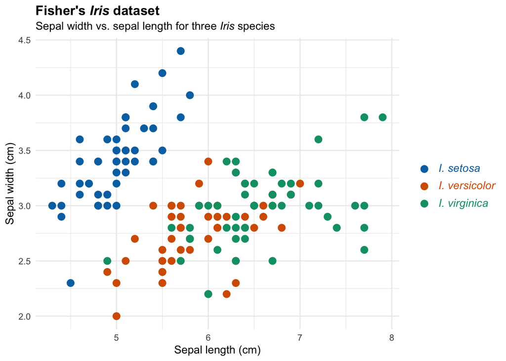

```r
library(ggtext)

ggplot(iris, aes(Sepal.Length, Sepal.Width, color = Species)) +
  geom_point(size = 3) +
  scale_color_manual(
    name = NULL,
    values = c(setosa = "#0072B2", virginica = "#009E73", versicolor = "#D55E00"),
    labels = c(
      setosa = "<i style='color:#0072B2'>I. setosa</i>",
      virginica = "<i style='color:#009E73'>I. virginica</i>",
      versicolor = "<i style='color:#D55E00'>I. versicolor</i>")
  ) +
  labs(
    title = "**Fisher's *Iris* dataset**
    <span style='font-size:11pt'>Sepal width vs. sepal length for three *Iris*
    species</span>",
    x = "Sepal length (cm)", y = "Sepal width (cm)"
  ) +
  theme_minimal() +
  theme(
    plot.title = element_markdown(lineheight = 1.1),
    legend.text = element_markdown(size = 11)
  )
```

### Example 2

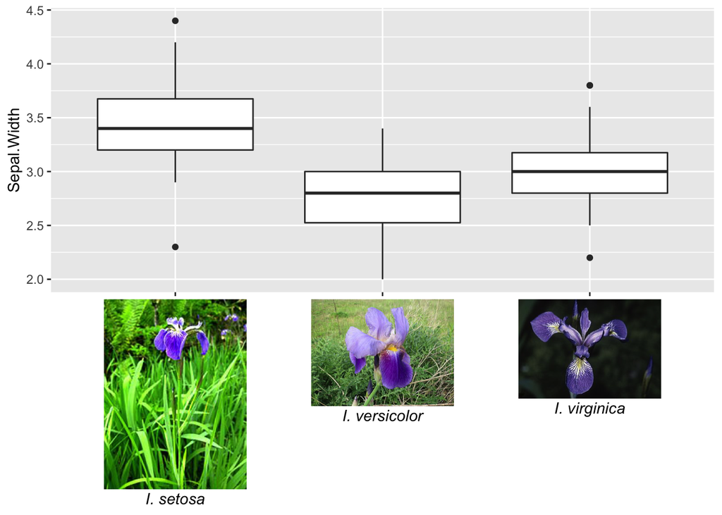

```r
labels <- c(
  setosa = "<img src='https://upload.wikimedia.org/wikipedia/commons/thumb/8/86/Iris_setosa.JPG/180px-Iris_setosa.JPG'
    width='100' /><br>*I. setosa*",
  virginica = "<img src='https://upload.wikimedia.org/wikipedia/commons/thumb/3/38/Iris_virginica_-_NRCS.jpg/320px-Iris_virginica_-_NRCS.jpg'
    width='100' /><br>*I. virginica*",
  versicolor = "<img src='https://upload.wikimedia.org/wikipedia/commons/thumb/2/27/20140427Iris_versicolor1.jpg/320px-20140427Iris_versicolor1.jpg'
    width='100' /><br>*I. versicolor*"
)

ggplot(iris, aes(Species, Sepal.Width)) +
  geom_boxplot() +
  scale_x_discrete(
    name = NULL,
    labels = labels
  ) +
  theme(
    axis.text.x = element_markdown(color = "black", size = 11)
  )
```

For more examples and to hear about the motivation behind this package, you can watch Claus Wilke’s [talk](https://resources.rstudio.com/rstudio-conf-2020/spruce-up-your-ggplot2-visualizations-with-formatted-text-claus-wilke).

# What They Forgot To Teach You About R

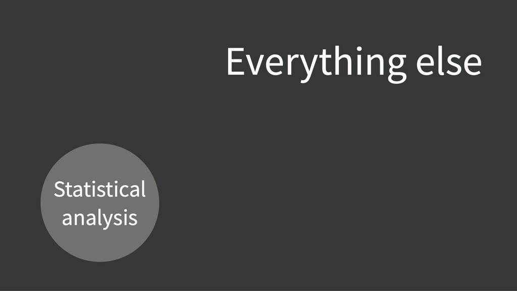

```r
fs::path_home("tmp/test.csv")
```

```
## /Users/RASV5G/tmp/test.csv
```

```r
ggsave(here::here("figs", "figure1.png"))
```

- Debugging Code
  - `traceback()`: prints the sequence of calls that lead to the error
  - put `print()` or `str()` statements throughout your functions
  - `browser()`: Interrupt the execution of an expression and allow the inspection of the environment where browser was called from.
- Personal R Administration
  - `.Renviron` (good for API keys)
  - `.Rprofile`
- Iteration with `{purrr}`

```r
library(purrr)

mtcars %>%
  group_by(cyl) %>%
  nest() %>%
  mutate(lm = map(data, ~lm(mpg ~ wt, data = .x)),
         summary = map(lm, summary),
         r_squared = map_dbl(summary, "r.squared"))
```

| cyl | data | lm | summary | r_squared |
| --- | --- | --- | --- | --- |
| 6 |  |  |  | 0.4645102 |
| 4 |  |  |  | 0.5086326 |
| 8 |  |  |  | 0.4229655 |

### Resources

- [WTF online book](https://rstats.wtf/)
- [RStudio::conf WTF workshop website](https://rstudio-conf-2020.github.io/what-they-forgot/)
- [Happy Git with R online book](https://happygitwithr.com/)
- [Good enough practices in scientific computing article](https://journals.plos.org/ploscompbiol/article?id=10.1371/journal.pcbi.1005510)